# Untitled

The codes can be simplified as below:

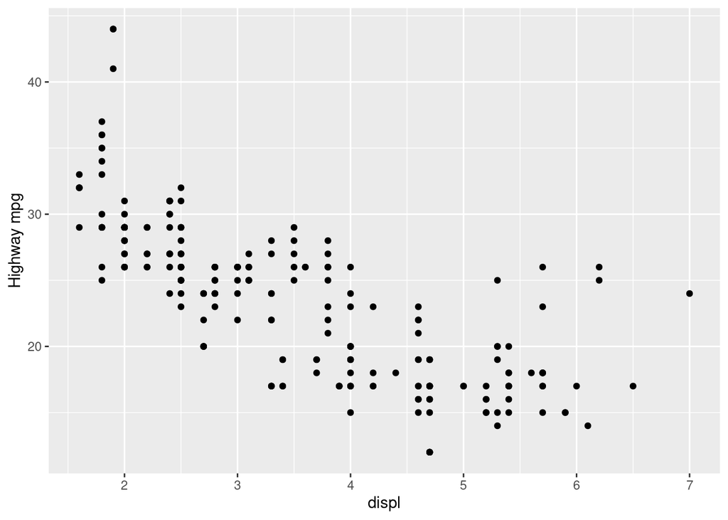

```r
ggplot(mpg, aes(displ, hwy)) +
  geom_point() +
  ylab("Highway mpg")
```

This can be simplified down to:

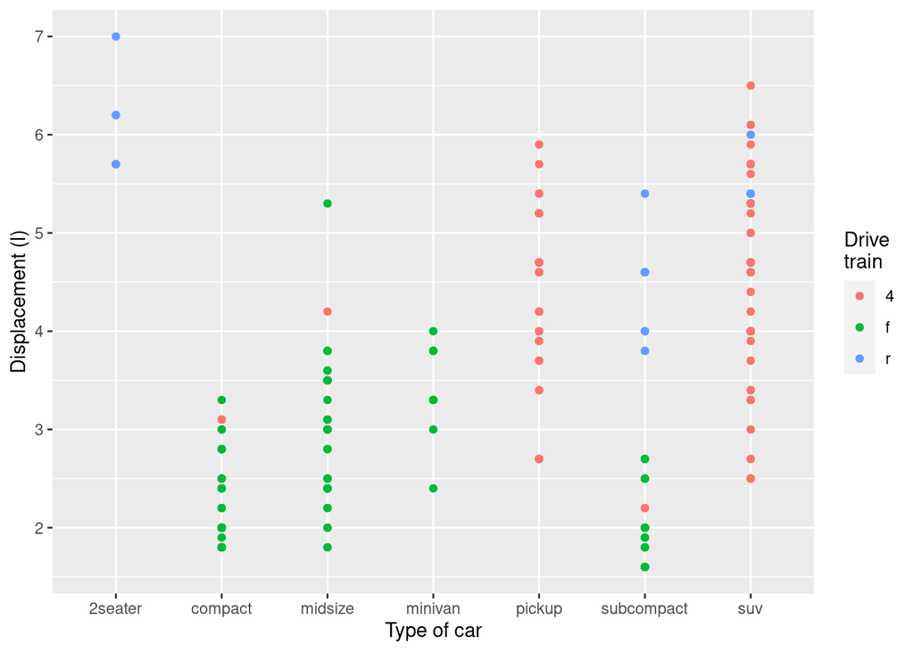

```r
ggplot(mpg, aes(class, displ)) +
  geom_point(aes(color = drv)) +
  labs(x = "Type of car", y = "Displacement (l)", colour = "Drive\ntrain")
```

24. שחזר את הגרף הבא, סדר את תווית ציר y כך שהסוגריים יהיו בגודל הנכון

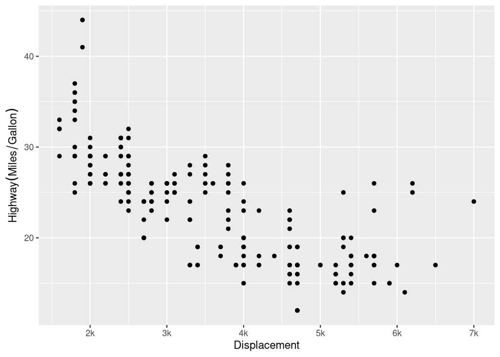

```r
ggplot(mpg, aes(displ, hwy)) +
  geom_point() +
  scale_x_continuous("Displacement",
                     breaks = c(2,3,4,5,6,7),
                     labels = c("2k", "3k", "4k", "5k", "6k", "7k")) +
  scale_y_continuous(quote(Highway (Miles/Gallon)))
```

25. שחזר את הגרף הבא:

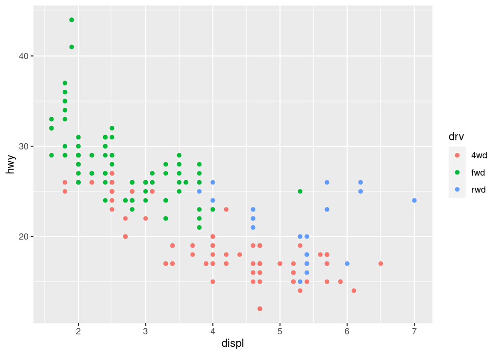

```r
ggplot(mpg, aes(displ, hwy, color = drv)) +
  geom_point() +
  scale_color_discrete(labels = c("4wd", "fwd", "rwd"))
```

26. מה הבעיה בגרף המיוצר באמצעות ggplot(mpg, aes(displ, hwy)) +geom_point(aes(colour = drv, shape = drv)) + scale_colour_discrete(“Drive train”) כיצד ניתן לתקן זאת?

The plot created two legends on the right-hand side, where you could just use one.

Here, quoting from the book:“In order for legends to be merged, they must have the same name. So if you change the name of one of the scales, you’ll need to change it for all of them.”

As a result, here, the original plot sets only colour with new name, while shape doesn’t have the same new name, the result is that these two legends cannot merge. There are two ways to fix this plot:

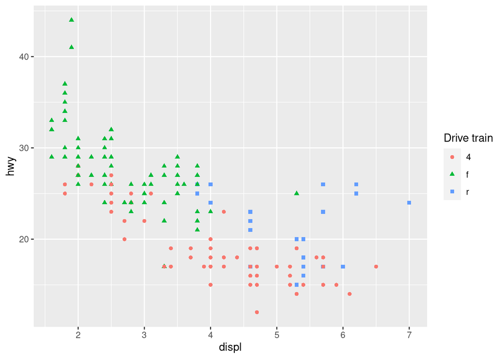

```r
ggplot(mpg, aes(displ, hwy)) +
geom_point(aes(color = drv, shape = drv)) +
  labs(color = "Drive train", shape = "Drive train")
```

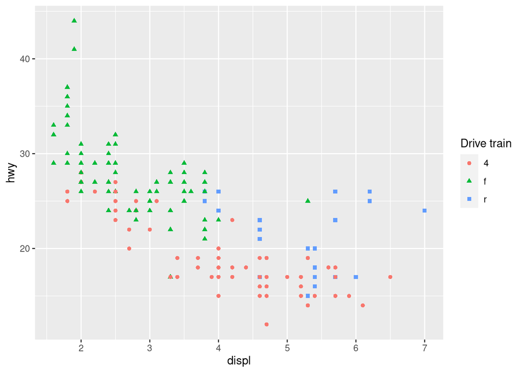

```r
ggplot(mpg, aes(displ, hwy)) +
  geom_point(aes(colour = drv, shape = drv)) +
  scale_colour_discrete("Drive train") +
  scale_shape_discrete("Drive train")
```

27. צור את הגרף
28. הקוד הבא מייצר שני גרפים. שנה את הקוד כך שהצירים והמקרא יהיו זהים (אין להשתמש ב facets) fwd <- subset(mpg, drv == “f”) rwd <- subset(mpg, drv == “r”) ggplot(fwd, aes(displ, hwy, colour = class)) + geom_point() ggplot(rwd, aes(displ, hwy, colour = class)) + geom_point()

We can also set the xlim and ylim so that both plots have the same axes scales. But this is optional.

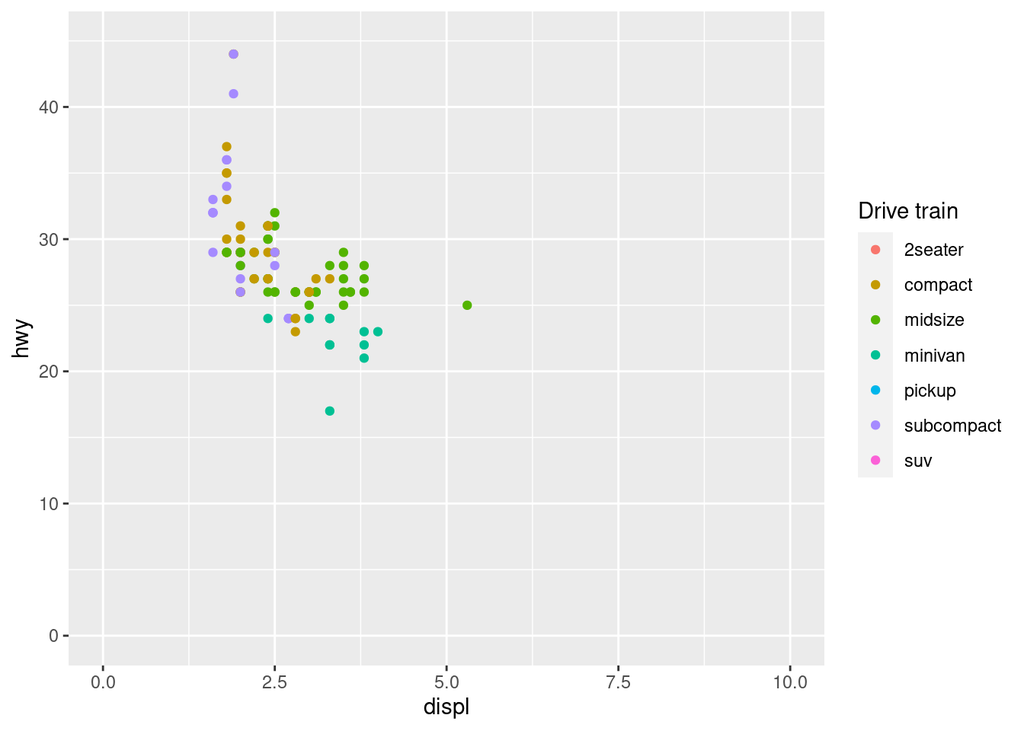

```r
fwd <- subset(mpg, drv == "f")
rwd <- subset(mpg, drv == "r")
ggplot(fwd, aes(displ, hwy, colour = class)) +
  geom_point() +
  scale_color_discrete("Drive train") +
  xlim(0, 10) +
  ylim(0, 45) +
  expand_limits(color = c("2seater", "compact", "midsize", "minivan",
                                   "pickup", "subcompact", "suv"))
```

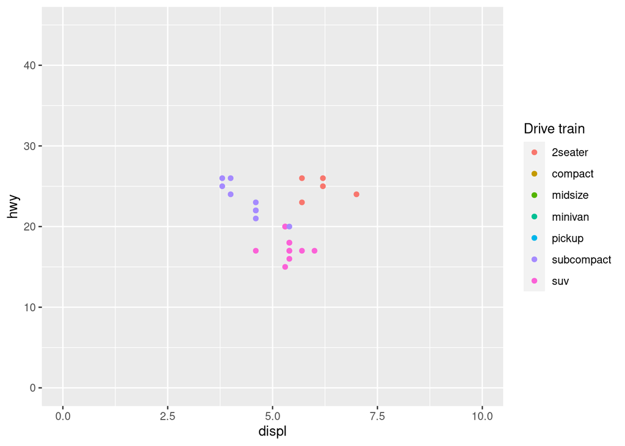

```r
ggplot(rwd, aes(displ, hwy, colour = class)) +
  geom_point() +
  scale_color_discrete("Drive train")+
  xlim(0, 10) +
  ylim(0, 45) +
  expand_limits(color = c("2seater", "compact", "midsize", "minivan",
                                   "pickup", "subcompact", "suv"))
```